# INSPIRE, GO, and Pfam Petal Comparison

Gurkan Bebek

July 29, 2026

```r
required_packages <- c(
  "DBI", "RSQLite", "dplyr", "tidyr", "readr", "stringr",
  "ggplot2", "igraph", "pheatmap", "patchwork"
)

missing_packages <- required_packages[
  !vapply(required_packages, requireNamespace, logical(1), quietly = TRUE)
]

if (length(missing_packages) > 0) {
  stop(
    "Install these R packages before knitting: ",
    paste(missing_packages, collapse = ", ")
  )
}

library(DBI)
library(RSQLite)
library(dplyr)
library(tidyr)
library(readr)
library(stringr)
library(ggplot2)
library(igraph)
library(pheatmap)
library(patchwork)

set.seed(params$random_seed)
dir.create(params$output_dir, recursive = TRUE, showWarnings = FALSE)
```

# 1 Analysis design

This report compares petals in three separate ways:

1. **INSPIRE network similarity**: the normalized C++ network-alignment score.
2. **GO petal-gene similarity**: only genes belonging to the two petals being compared are used. Cached GO scores are retrieved only for cross-petal gene pairs.
3. **Pfam petal-gene similarity**: only genes belonging to the two petals being compared are used. Pfam Jaccard scores are calculated only for cross-petal gene pairs.

GO and Pfam are not recalculated through INSPIRE and do not use network topology.

For each petal pair, GO and Pfam use a symmetric best-match average. If petal `A` has genes `a` and petal `B` has genes `b`:

$$S(A,B) = \frac{1}{2}
\left[
\frac{1}{|A|}\sum_{a \in A}\max_{b \in B}s(a,b)
+
\frac{1}{|B|}\sum_{b \in B}\max_{a \in A}s(a,b)
\right]$$

Thus, every gene is compared only with genes in the petal on the opposite side of the current comparison. No genes outside the current two petals contribute to that petal-pair score.

The diagonal is defined as 1.0. Self-alignments are not read from INSPIRE logs.

Two clustering approaches are shown independently:

- ordinary hierarchical clustering with `hclust`
- item-resampling consensus hierarchical clustering

# 2 Connect to SQLite and validate inputs

```r
if (!file.exists(params$database)) {
  stop("Database not found: ", params$database)
}

con <- DBI::dbConnect(RSQLite::SQLite(), params$database)

integrity <- DBI::dbGetQuery(con, "PRAGMA integrity_check")[[1]][1]
if (!identical(integrity, "ok")) {
  stop("SQLite integrity check failed: ", integrity)
}

foreign_key_errors <- DBI::dbGetQuery(con, "PRAGMA foreign_key_check")
if (nrow(foreign_key_errors) > 0) {
  stop("SQLite foreign-key check returned errors")
}

petals <- DBI::dbGetQuery(
  con,
  "SELECT petal, gene_count, edge_count FROM petal ORDER BY petal"
)

petal_names <- petals$petal
n_petals <- length(petal_names)

if (n_petals < 3) {
  stop("At least three petals are required")
}

petal_genes <- DBI::dbGetQuery(
  con,
  paste(
    "SELECT pg.petal, pg.gene_symbol, gu.uniprot_accession",
    "FROM petal_gene AS pg",
    "JOIN gene_uniprot AS gu",
    "  ON gu.gene_symbol = pg.gene_symbol",
    " AND gu.is_preferred = 1",
    "ORDER BY pg.petal, pg.gene_symbol"
  )
)

if (nrow(petal_genes) != sum(petals$gene_count)) {
  stop("Petal gene count does not match preferred UniProt mappings")
}

petal_gene_lists <- split(petal_genes$gene_symbol, petal_genes$petal)
petal_protein_lists <- split(petal_genes$uniprot_accession, petal_genes$petal)

petals
```

```
##      petal gene_count edge_count
## 1    ABCA1          6          6
## 2     BCL9          4          3
## 3    ERCC6          7          8
## 4    FBXW7         27         52
## 5      FN1         10         15
## 6     GLI3          6          7
## 7   IGFBP3          4          3
## 8     KRAS         23         44
## 9    MAP1B          4          3
## 10  MCM3AP          4          3
## 11    MMP2          5          5
## 12    NAV3          4          3
## 13     NF1         13         20
## 14  PIK3CA         25         46
## 15   PLCG2          4          3
## 16   PRKD1          7          8
## 17    PTEN         43         94
## 18 RUNX1T1          4          3
## 19   SMAD2         44         94
## 20   SMAD3         18         29
## 21   SMAD4         25         48
## 22    TAF2          6          6
## 23  TCF7L2         11         17
## 24  TGFBR2         20         32
## 25   TIAM1          6          7
## 26   UHRF2          5          5
## 27  ZNF521          4          3
```

# 3 Helper functions

```r
empty_similarity_matrix <- function(names) {
  matrix(
    NA_real_,
    nrow = length(names),
    ncol = length(names),
    dimnames = list(names, names)
  )
}

validate_similarity <- function(m, label) {
  if (!is.matrix(m) || nrow(m) != ncol(m)) {
    stop(label, " is not a square matrix")
  }
  if (!identical(rownames(m), colnames(m))) {
    stop(label, " row and column names differ")
  }
  if (anyNA(m)) {
    missing <- which(is.na(m), arr.ind = TRUE)[1, ]
    stop(
      label, " contains a missing value for ",
      rownames(m)[missing[1]], " and ", colnames(m)[missing[2]]
    )
  }
  if (max(abs(m - t(m))) > 1e-10) {
    stop(label, " is not symmetric")
  }
  if (any(m < -1e-10 | m > 1 + 1e-10)) {
    stop(label, " contains a value outside [0, 1]")
  }
  invisible(TRUE)
}

long_pairs_to_matrix <- function(df, names) {
  m <- empty_similarity_matrix(names)
  diag(m) <- 1

  for (i in seq_len(nrow(df))) {
    a <- df$petal_a[i]
    b <- df$petal_b[i]
    value <- df$score[i]

    if (a %in% names && b %in% names && is.finite(value)) {
      m[a, b] <- value
      m[b, a] <- value
    }
  }

  diag(m) <- 1
  m
}

matrix_to_long <- function(m, method) {
  as.data.frame(as.table(m), stringsAsFactors = FALSE) |>
    transmute(
      petal_a = as.character(Var1),
      petal_b = as.character(Var2),
      score = as.numeric(Freq),
      method = method
    ) |>
    filter(petal_a < petal_b)
}

symmetric_best_match_average <- function(score_matrix) {
  if (!is.matrix(score_matrix) || nrow(score_matrix) == 0 || ncol(score_matrix) == 0) {
    return(NA_real_)
  }
  if (anyNA(score_matrix)) {
    return(NA_real_)
  }

  a_to_b <- mean(apply(score_matrix, 1, max))
  b_to_a <- mean(apply(score_matrix, 2, max))
  (a_to_b + b_to_a) / 2
}

cluster_with_hclust <- function(similarity, k, linkage = "average") {
  distance <- as.dist(1 - similarity)
  tree <- hclust(distance, method = linkage)
  clusters <- cutree(tree, k = k)
  list(tree = tree, clusters = clusters)
}

consensus_for_k <- function(
    similarity,
    k,
    reps = 1000,
    item_fraction = 0.8,
    linkage = "average",
    seed = 1) {

  set.seed(seed + k)
  n <- nrow(similarity)
  sample_n <- max(k + 1L, ceiling(n * item_fraction))
  sample_n <- min(sample_n, n)

  co_sampled <- matrix(0L, n, n, dimnames = dimnames(similarity))
  co_clustered <- matrix(0L, n, n, dimnames = dimnames(similarity))

  for (iteration in seq_len(reps)) {
    idx <- sort(sample.int(n, sample_n, replace = FALSE))
    sub_similarity <- similarity[idx, idx, drop = FALSE]
    tree <- hclust(as.dist(1 - sub_similarity), method = linkage)
    group <- cutree(tree, k = k)

    co_sampled[idx, idx] <- co_sampled[idx, idx] + 1L
    same_group <- outer(group, group, FUN = "==")
    co_clustered[idx, idx] <- co_clustered[idx, idx] + same_group
  }

  consensus <- matrix(NA_real_, n, n, dimnames = dimnames(similarity))
  observed <- co_sampled > 0
  consensus[observed] <- co_clustered[observed] / co_sampled[observed]
  diag(consensus) <- 1

  final_tree <- hclust(as.dist(1 - consensus), method = linkage)
  final_clusters <- cutree(final_tree, k = k)

  off_diagonal <- consensus[upper.tri(consensus)]
  pac <- mean(off_diagonal > 0.1 & off_diagonal < 0.9, na.rm = TRUE)

  list(
    k = k,
    consensus = consensus,
    tree = final_tree,
    clusters = final_clusters,
    pac = pac
  )
}

run_consensus <- function(similarity, max_k, reps, item_fraction, seed) {
  max_k <- min(max_k, nrow(similarity) - 1L)

  results <- lapply(2:max_k, function(k) {
    consensus_for_k(
      similarity = similarity,
      k = k,
      reps = reps,
      item_fraction = item_fraction,
      seed = seed
    )
  })

  metrics <- bind_rows(lapply(results, function(result) {
    tibble(k = result$k, PAC = result$pac)
  }))

  best_k <- metrics$k[order(metrics$PAC, metrics$k)][1]
  best_result <- results[[which(vapply(results, function(x) x$k, integer(1)) == best_k)]]

  list(results = results, metrics = metrics, best = best_result)
}
```

# 4 1. INSPIRE network similarity

```r
if (!dir.exists(params$inspire_log_dir)) {
  stop("INSPIRE log directory not found: ", params$inspire_log_dir)
}

log_files <- list.files(
  params$inspire_log_dir,
  pattern = "\\.log$",
  full.names = TRUE
)

if (length(log_files) == 0) {
  stop("No INSPIRE log files found")
}

parse_inspire_log <- function(path) {
  text <- paste(readLines(path, warn = FALSE), collapse = "\n")

  matches <- stringr::str_match_all(
    text,
    "\\$RESULT\\$\\s+(\\S+)\\s+(\\S+)\\s+norm_score:\\s+(-?[0-9.]+(?:[eE][+-]?[0-9]+)?)"
  )[[1]]

  if (nrow(matches) == 0) {
    return(tibble(
      log_file = path,
      petal_a = NA_character_,
      petal_b = NA_character_,
      score = NA_real_,
      status = "incomplete"
    ))
  }

  last_result <- matches[nrow(matches), ]

  tibble(
    log_file = path,
    petal_a = last_result[2],
    petal_b = last_result[3],
    score = as.numeric(last_result[4]),
    status = "complete"
  )
}

inspire_logs <- bind_rows(lapply(log_files, parse_inspire_log))

inspire_pairs <- inspire_logs |>
  filter(
    status == "complete",
    !is.na(petal_a),
    !is.na(petal_b),
    petal_a != petal_b
  ) |>
  mutate(
    first = pmin(petal_a, petal_b),
    second = pmax(petal_a, petal_b)
  ) |>
  group_by(first, second) |>
  summarise(score = last(score), .groups = "drop") |>
  transmute(petal_a = first, petal_b = second, score = score)

inspire_similarity <- long_pairs_to_matrix(inspire_pairs, petal_names)
validate_similarity(inspire_similarity, "INSPIRE similarity")

write.csv(
  inspire_similarity,
  file.path(params$output_dir, "similarity_inspire.csv"),
  quote = FALSE
)
```

# 5 2. GO similarity using only genes in each petal pair

For each pair of petals, this section queries only the cross-product of the genes in those two petals. No gene outside those two petals enters the BMA calculation.

GO scores are normalized by the maximum score for the selected GO algorithm. The maximum is a fixed scale factor only; it does not add any outside genes to a petal-pair comparison.

```r
go_max <- DBI::dbGetQuery(
  con,
  "SELECT MAX(score) AS maximum FROM go_pair_score WHERE algorithm = ?",
  params = list(params$go_algorithm)
)$maximum[1]

if (!is.finite(go_max) || go_max <= 0) {
  stop("Invalid GO maximum for algorithm: ", params$go_algorithm)
}

get_go_cross_matrix <- function(petal_a, petal_b) {
  genes_a <- petal_genes |>
    filter(petal == petal_a) |>
    select(gene_a = gene_symbol, protein_a = uniprot_accession)

  genes_b <- petal_genes |>
    filter(petal == petal_b) |>
    select(gene_b = gene_symbol, protein_b = uniprot_accession)

  requested <- tidyr::crossing(genes_a, genes_b) |>
    mutate(
      protein1 = pmin(protein_a, protein_b),
      protein2 = pmax(protein_a, protein_b)
    )

  placeholders <- paste(rep("(?, ?)", nrow(requested)), collapse = ", ")
  sql <- paste0(
    "WITH requested(protein1, protein2) AS (VALUES ", placeholders, ") ",
    "SELECT r.protein1, r.protein2, s.score ",
    "FROM requested AS r ",
    "LEFT JOIN go_pair_score AS s ",
    "  ON s.protein1 = r.protein1 ",
    " AND s.protein2 = r.protein2 ",
    " AND s.algorithm = ?"
  )

  bind_values <- as.list(as.vector(t(as.matrix(requested[, c("protein1", "protein2")]))) )
  bind_values <- c(bind_values, params$go_algorithm)

  scores <- DBI::dbGetQuery(con, sql, params = bind_values)

  requested <- requested |>
    left_join(scores, by = c("protein1", "protein2"))

  if (anyNA(requested$score)) {
    missing <- requested |>
      filter(is.na(score)) |>
      slice(1)
    stop(
      "Missing GO score for ", missing$gene_a, " and ", missing$gene_b,
      " while comparing ", petal_a, " and ", petal_b
    )
  }

  matrix(
    requested$score / go_max,
    nrow = nrow(genes_a),
    ncol = nrow(genes_b),
    byrow = FALSE,
    dimnames = list(genes_a$gene_a, genes_b$gene_b)
  )
}

go_similarity <- empty_similarity_matrix(petal_names)
diag(go_similarity) <- 1

go_pair_details <- list()
detail_index <- 1L

for (i in seq_along(petal_names)) {
  for (j in i:length(petal_names)) {
    petal_a <- petal_names[i]
    petal_b <- petal_names[j]

    if (petal_a == petal_b) {
      value <- 1
    } else {
      cross_scores <- get_go_cross_matrix(petal_a, petal_b)
      value <- symmetric_best_match_average(cross_scores)

      go_pair_details[[detail_index]] <- as.data.frame(as.table(cross_scores)) |>
        transmute(
          petal_a = petal_a,
          petal_b = petal_b,
          gene_a = as.character(Var1),
          gene_b = as.character(Var2),
          normalized_go_score = as.numeric(Freq)
        )
      detail_index <- detail_index + 1L
    }

    go_similarity[petal_a, petal_b] <- value
    go_similarity[petal_b, petal_a] <- value
  }
}
validate_similarity(go_similarity, "GO petal-gene similarity")

write.csv(
  go_similarity,
  file.path(params$output_dir, "similarity_go_petal_genes.csv"),
  quote = FALSE
)

write_csv(
  bind_rows(go_pair_details),
  file.path(params$output_dir, "go_cross_petal_gene_scores.csv")
)
```

# 6 3. Pfam similarity using only genes in each petal pair

For each pair of petals, Pfam Jaccard similarity is calculated only for the cross-product of genes in those two petals.

```r
pfam_rows <- DBI::dbGetQuery(
  con,
  paste(
    "SELECT uniprot_accession, pfam_accession",
    "FROM protein_pfam",
    "ORDER BY uniprot_accession, pfam_accession"
  )
)

pfam_by_protein <- split(
  pfam_rows$pfam_accession,
  pfam_rows$uniprot_accession
)

pfam_jaccard <- function(protein_a, protein_b) {
  domains_a <- unique(pfam_by_protein[[protein_a]])
  domains_b <- unique(pfam_by_protein[[protein_b]])

  if (is.null(domains_a)) domains_a <- character()
  if (is.null(domains_b)) domains_b <- character()

  union_domains <- union(domains_a, domains_b)

  if (length(union_domains) == 0) {
    return(0)
  }

  length(intersect(domains_a, domains_b)) / length(union_domains)
}

get_pfam_cross_matrix <- function(petal_a, petal_b) {
  genes_a <- petal_genes |>
    filter(petal == petal_a) |>
    select(gene_a = gene_symbol, protein_a = uniprot_accession)

  genes_b <- petal_genes |>
    filter(petal == petal_b) |>
    select(gene_b = gene_symbol, protein_b = uniprot_accession)

  requested <- tidyr::crossing(genes_a, genes_b) |>
    rowwise() |>
    mutate(score = pfam_jaccard(protein_a, protein_b)) |>
    ungroup()

  matrix(
    requested$score,
    nrow = nrow(genes_a),
    ncol = nrow(genes_b),
    byrow = FALSE,
    dimnames = list(genes_a$gene_a, genes_b$gene_b)
  )
}

pfam_similarity <- empty_similarity_matrix(petal_names)
diag(pfam_similarity) <- 1

pfam_pair_details <- list()
detail_index <- 1L

for (i in seq_along(petal_names)) {
  for (j in i:length(petal_names)) {
    petal_a <- petal_names[i]
    petal_b <- petal_names[j]

    if (petal_a == petal_b) {
      value <- 1
    } else {
      cross_scores <- get_pfam_cross_matrix(petal_a, petal_b)
      value <- symmetric_best_match_average(cross_scores)

      pfam_pair_details[[detail_index]] <- as.data.frame(as.table(cross_scores)) |>
        transmute(
          petal_a = petal_a,
          petal_b = petal_b,
          gene_a = as.character(Var1),
          gene_b = as.character(Var2),
          pfam_jaccard = as.numeric(Freq)
        )
      detail_index <- detail_index + 1L
    }

    pfam_similarity[petal_a, petal_b] <- value
    pfam_similarity[petal_b, petal_a] <- value
  }
}

validate_similarity(pfam_similarity, "Pfam petal-gene similarity")

write.csv(
  pfam_similarity,
  file.path(params$output_dir, "similarity_pfam_petal_genes.csv"),
  quote = FALSE
)

write_csv(
  bind_rows(pfam_pair_details),
  file.path(params$output_dir, "pfam_cross_petal_gene_scores.csv")
)
```

# 7 Similarity distributions and matrix associations

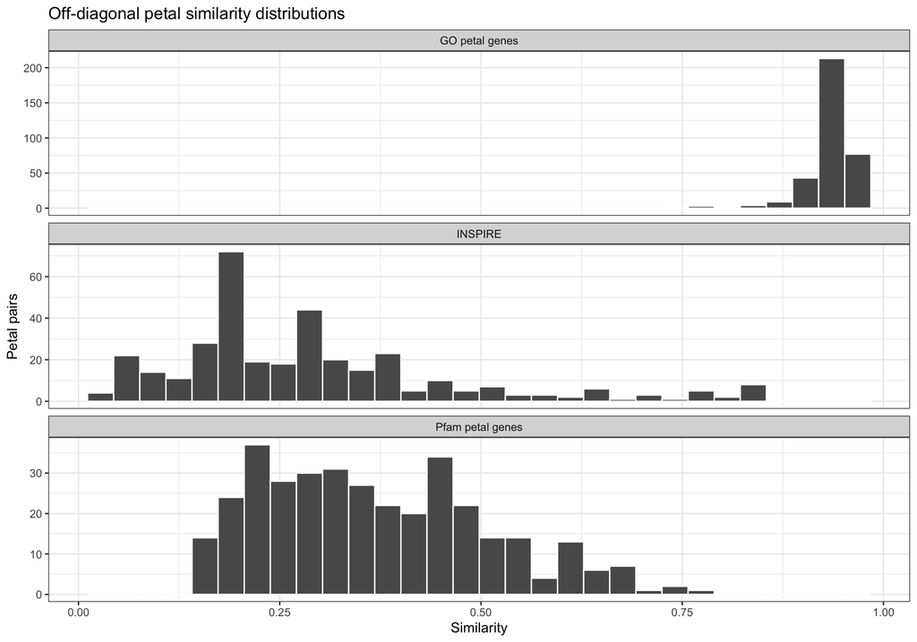

```r
all_similarity_long <- bind_rows(
  matrix_to_long(inspire_similarity, "INSPIRE"),
  matrix_to_long(go_similarity, "GO petal genes"),
  matrix_to_long(pfam_similarity, "Pfam petal genes")
)

write_csv(
  all_similarity_long,
  file.path(params$output_dir, "all_similarity_pairs_long.csv")
)

ggplot(all_similarity_long, aes(score)) +
  geom_histogram(bins = 30, color = "white") +
  facet_wrap(~method, ncol = 1, scales = "free_y") +
  labs(
    title = "Off-diagonal petal similarity distributions",
    x = "Similarity",
    y = "Petal pairs"
  ) +
  theme_bw()
```

```r
score_wide <- all_similarity_long |>
  select(petal_a, petal_b, method, score) |>
  pivot_wider(names_from = method, values_from = score)

numeric_scores <- score_wide |>
  select(where(is.numeric))

pearson_correlations <- cor(numeric_scores, method = "pearson")
spearman_correlations <- cor(numeric_scores, method = "spearman")

write.csv(
  pearson_correlations,
  file.path(params$output_dir, "matrix_correlations_pearson.csv")
)

write.csv(
  spearman_correlations,
  file.path(params$output_dir, "matrix_correlations_spearman.csv")
)

pearson_correlations
```

```
##                    INSPIRE GO petal genes Pfam petal genes
## INSPIRE          1.0000000      0.4682159        0.7228851
## GO petal genes   0.4682159      1.0000000        0.4123295
## Pfam petal genes 0.7228851      0.4123295        1.0000000
```

```r
spearman_correlations
```

```
##                    INSPIRE GO petal genes Pfam petal genes
## INSPIRE          1.0000000      0.6479347        0.7476995
## GO petal genes   0.6479347      1.0000000        0.6252947
## Pfam petal genes 0.7476995      0.6252947        1.0000000
```

# 8 High-confidence INSPIRE graph

```r
inspire_long <- matrix_to_long(inspire_similarity, "INSPIRE")

threshold_edges <- inspire_long |>
  filter(score > params$inspire_threshold) |>
  select(from = petal_a, to = petal_b, weight = score)

threshold_graph <- igraph::graph_from_data_frame(
  threshold_edges,
  directed = FALSE,
  vertices = tibble(name = petal_names)
)

component_membership <- igraph::components(threshold_graph)$membership

threshold_components <- tibble(
  petal = names(component_membership),
  component = as.integer(component_membership)
) |>
  group_by(component) |>
  mutate(component_size = n()) |>
  ungroup() |>
  arrange(desc(component_size), component, petal)

write_csv(
  threshold_components,
  file.path(params$output_dir, "inspire_threshold_components.csv")
)

threshold_components
```

```
## # A tibble: 27 × 3
##    petal  component component_size
##    <chr>      <int>          <int>
##  1 ABCA1          1             14
##  2 FBXW7          1             14
##  3 FN1            1             14
##  4 KRAS           1             14
##  5 MMP2           1             14
##  6 NF1            1             14
##  7 PIK3CA         1             14
##  8 PLCG2          1             14
##  9 PTEN           1             14
## 10 SMAD2          1             14
## # ℹ 17 more rows
```

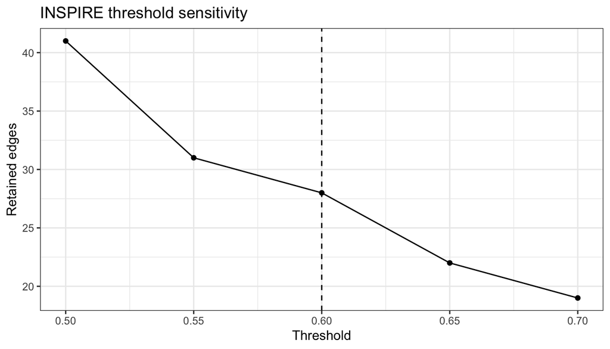

```r
threshold_summary <- tibble(
  threshold = seq(0.50, 0.70, by = 0.05)
) |>
  rowwise() |>
  mutate(
    retained_edges = sum(inspire_long$score > threshold),
    retained_fraction = retained_edges / nrow(inspire_long)
  ) |>
  ungroup()

write_csv(
  threshold_summary,
  file.path(params$output_dir, "inspire_threshold_sensitivity.csv")
)

ggplot(threshold_summary, aes(threshold, retained_edges)) +
  geom_line() +
  geom_point() +
  geom_vline(xintercept = params$inspire_threshold, linetype = 2) +
  labs(
    title = "INSPIRE threshold sensitivity",
    x = "Threshold",
    y = "Retained edges"
  ) +
  theme_bw()
```

# 9 Hierarchical clustering with hclust

Hierarchical clustering is shown directly for all three similarity matrices. The default distance is `1 - similarity`, and average linkage is used.

The requested number of groups is initially taken from the best consensus result below. Dendrograms themselves do not depend on that choice.

```r
hc_inspire_tree <- hclust(as.dist(1 - inspire_similarity), method = "average")
hc_go_tree <- hclust(as.dist(1 - go_similarity), method = "average")
hc_pfam_tree <- hclust(as.dist(1 - pfam_similarity), method = "average")
```

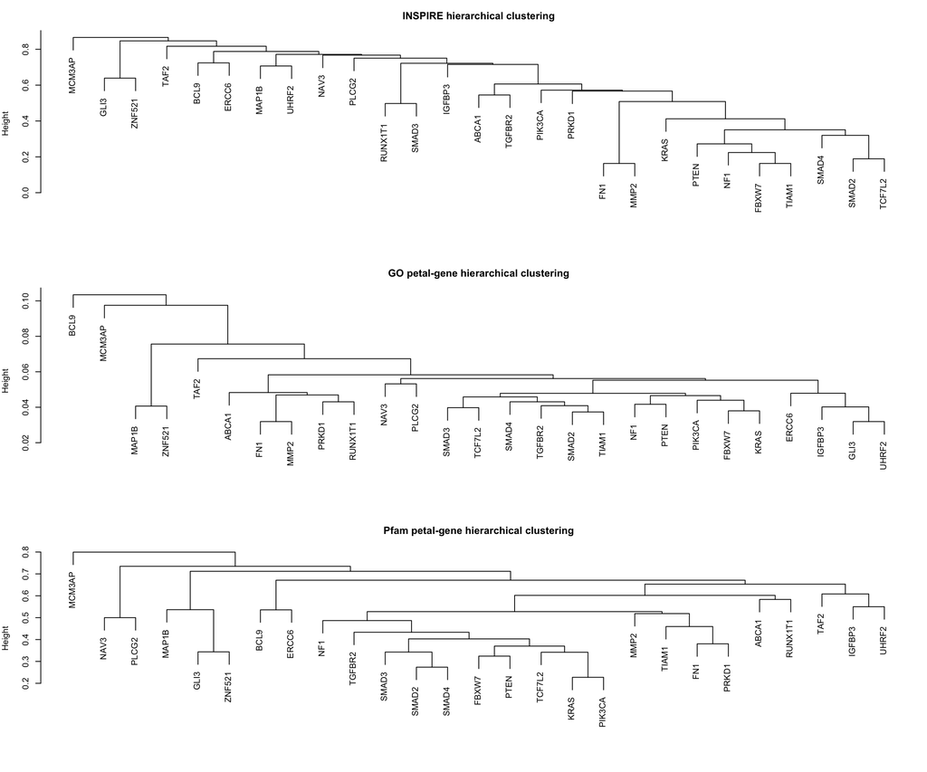

```r
old_par <- par(no.readonly = TRUE)
par(mfrow = c(3, 1), mar = c(4, 4, 3, 1))
plot(hc_inspire_tree, main = "INSPIRE hierarchical clustering", xlab = "", sub = "")
plot(hc_go_tree, main = "GO petal-gene hierarchical clustering", xlab = "", sub = "")
plot(hc_pfam_tree, main = "Pfam petal-gene hierarchical clustering", xlab = "", sub = "")
```

```r
par(old_par)
```

# 10 Consensus clustering

Consensus clustering is retained as a complementary stability analysis, not as the only clustering result.

```r
consensus_inspire <- run_consensus(
  inspire_similarity,
  params$max_k,
  params$consensus_reps,
  params$consensus_item_fraction,
  params$random_seed
)

consensus_go <- run_consensus(
  go_similarity,
  params$max_k,
  params$consensus_reps,
  params$consensus_item_fraction,
  params$random_seed + 10000
)

consensus_pfam <- run_consensus(
  pfam_similarity,
  params$max_k,
  params$consensus_reps,
  params$consensus_item_fraction,
  params$random_seed + 20000
)

consensus_metrics <- bind_rows(
  mutate(consensus_inspire$metrics, method = "INSPIRE"),
  mutate(consensus_go$metrics, method = "GO petal genes"),
  mutate(consensus_pfam$metrics, method = "Pfam petal genes")
)

write_csv(
  consensus_metrics,
  file.path(params$output_dir, "consensus_metrics.csv")
)

consensus_metrics
```

```
## # A tibble: 21 × 3
##        k   PAC method
##    <int> <dbl> <chr>
##  1     2 0.205 INSPIRE
##  2     3 0.197 INSPIRE
##  3     4 0.356 INSPIRE
##  4     5 0.387 INSPIRE
##  5     6 0.359 INSPIRE
##  6     7 0.291 INSPIRE
##  7     8 0.242 INSPIRE
##  8     2 0.205 GO petal genes
##  9     3 0.142 GO petal genes
## 10     4 0.405 GO petal genes
## # ℹ 11 more rows
```

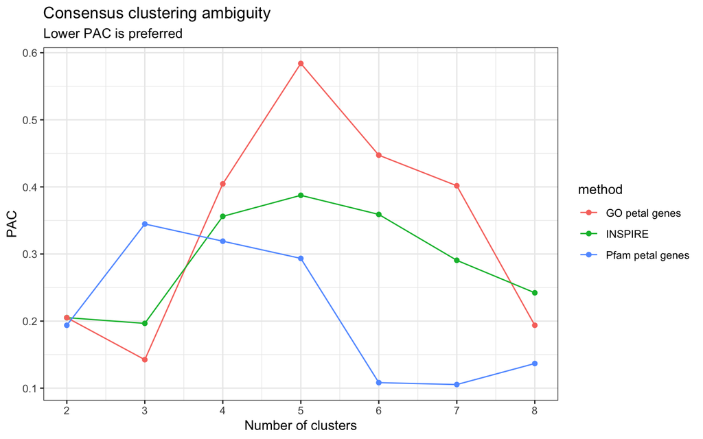

```r
ggplot(consensus_metrics, aes(k, PAC, color = method)) +
  geom_line() +
  geom_point() +
  scale_x_continuous(breaks = sort(unique(consensus_metrics$k))) +
  labs(
    title = "Consensus clustering ambiguity",
    subtitle = "Lower PAC is preferred",
    x = "Number of clusters",
    y = "PAC"
  ) +
  theme_bw()
```

# 11 Cluster assignments from both methods

The consensus-selected `k` is also used to cut each ordinary hierarchical tree so that the two approaches can be compared at the same number of clusters.

```r
k_inspire <- consensus_inspire$best$k
k_go <- consensus_go$best$k
k_pfam <- consensus_pfam$best$k

hclust_inspire <- cutree(hc_inspire_tree, k = k_inspire)
hclust_go <- cutree(hc_go_tree, k = k_go)
hclust_pfam <- cutree(hc_pfam_tree, k = k_pfam)

cluster_assignments <- tibble(
  petal = petal_names,
  inspire_hclust = unname(hclust_inspire[petal_names]),
  inspire_consensus = unname(consensus_inspire$best$clusters[petal_names]),
  go_hclust = unname(hclust_go[petal_names]),
  go_consensus = unname(consensus_go$best$clusters[petal_names]),
  pfam_hclust = unname(hclust_pfam[petal_names]),
  pfam_consensus = unname(consensus_pfam$best$clusters[petal_names])
)

selected_k <- tibble(
  method = c("INSPIRE", "GO petal genes", "Pfam petal genes"),
  selected_k = c(k_inspire, k_go, k_pfam),
  PAC = c(
    consensus_inspire$best$pac,
    consensus_go$best$pac,
    consensus_pfam$best$pac
  )
)

write_csv(
  cluster_assignments,
  file.path(params$output_dir, "cluster_assignments_hclust_and_consensus.csv")
)

write_csv(
  selected_k,
  file.path(params$output_dir, "selected_cluster_counts.csv")
)

selected_k
```

```
## # A tibble: 3 × 3
##   method           selected_k   PAC
##   <chr>                 <int> <dbl>
## 1 INSPIRE                   3 0.197
## 2 GO petal genes            3 0.142
## 3 Pfam petal genes          7 0.105
```

```r
cluster_assignments
```

```
## # A tibble: 27 × 7
##    petal  inspire_hclust inspire_consensus go_hclust go_consensus pfam_hclust
##    <chr>           <int>             <int>     <int>        <int>       <int>
##  1 ABCA1               1                 1         1            1           1
##  2 BCL9                1                 1         2            2           2
##  3 ERCC6               1                 1         1            1           2
##  4 FBXW7               1                 1         1            1           1
##  5 FN1                 1                 1         1            1           1
##  6 GLI3                2                 2         1            1           3
##  7 IGFBP3              1                 1         1            1           4
##  8 KRAS                1                 1         1            1           1
##  9 MAP1B               1                 1         1            1           3
## 10 MCM3AP              3                 3         3            3           5
## # ℹ 17 more rows
## # ℹ 1 more variable: pfam_consensus <int>
```

# 12 Hierarchical-clustering heatmaps

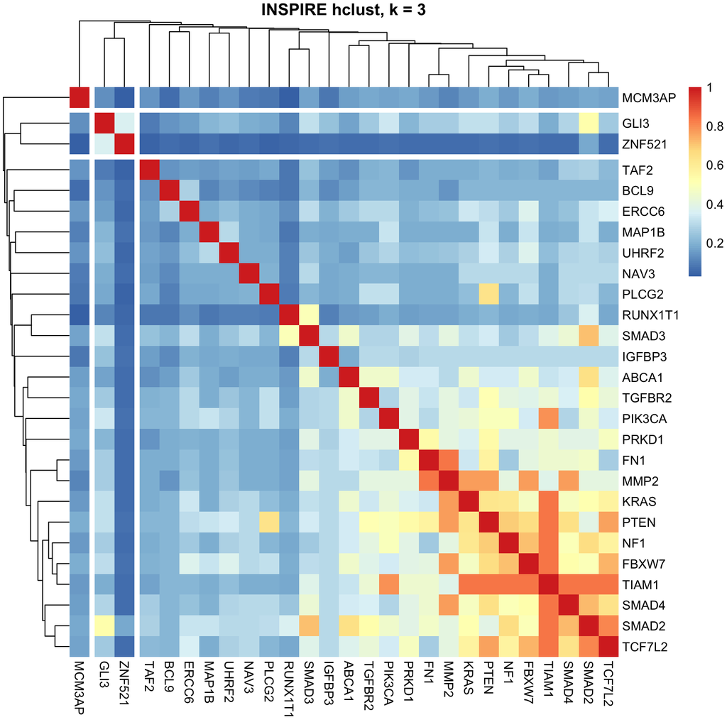

```r
pheatmap(
  inspire_similarity,
  clustering_distance_rows = as.dist(1 - inspire_similarity),
  clustering_distance_cols = as.dist(1 - inspire_similarity),
  clustering_method = "average",
  cutree_rows = k_inspire,
  cutree_cols = k_inspire,
  main = paste0("INSPIRE hclust, k = ", k_inspire),
  border_color = NA
)
```

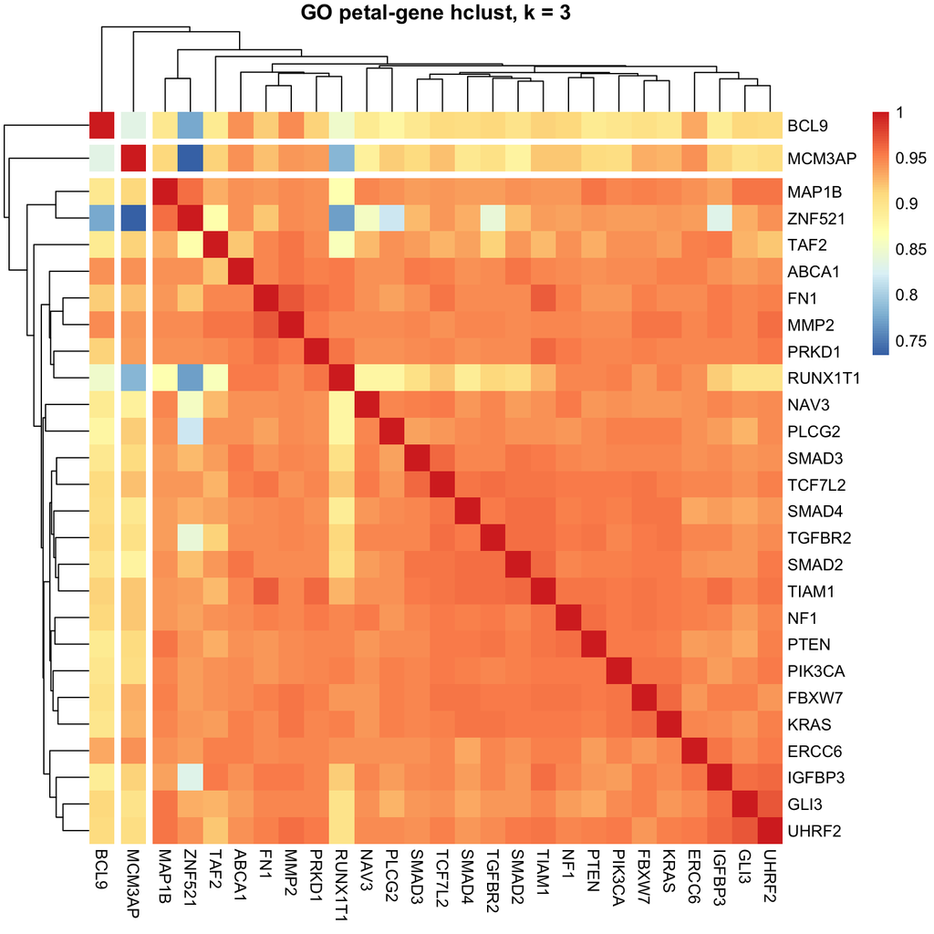

```r
pheatmap(
  go_similarity,
  clustering_distance_rows = as.dist(1 - go_similarity),
  clustering_distance_cols = as.dist(1 - go_similarity),
  clustering_method = "average",
  cutree_rows = k_go,
  cutree_cols = k_go,
  main = paste0("GO petal-gene hclust, k = ", k_go),
  border_color = NA
)
```

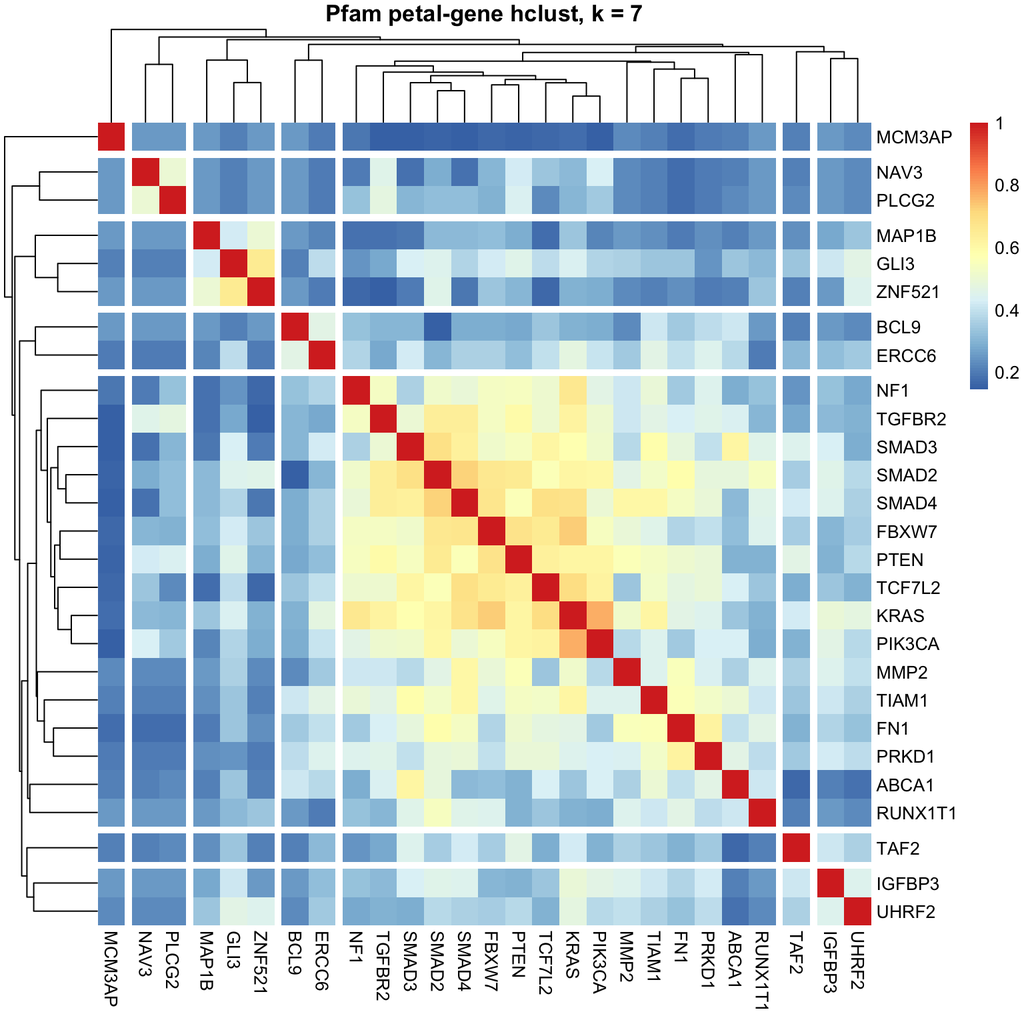

```r
pheatmap(
  pfam_similarity,
  clustering_distance_rows = as.dist(1 - pfam_similarity),
  clustering_distance_cols = as.dist(1 - pfam_similarity),
  clustering_method = "average",
  cutree_rows = k_pfam,
  cutree_cols = k_pfam,
  main = paste0("Pfam petal-gene hclust, k = ", k_pfam),
  border_color = NA
)
```

# 13 Consensus heatmaps

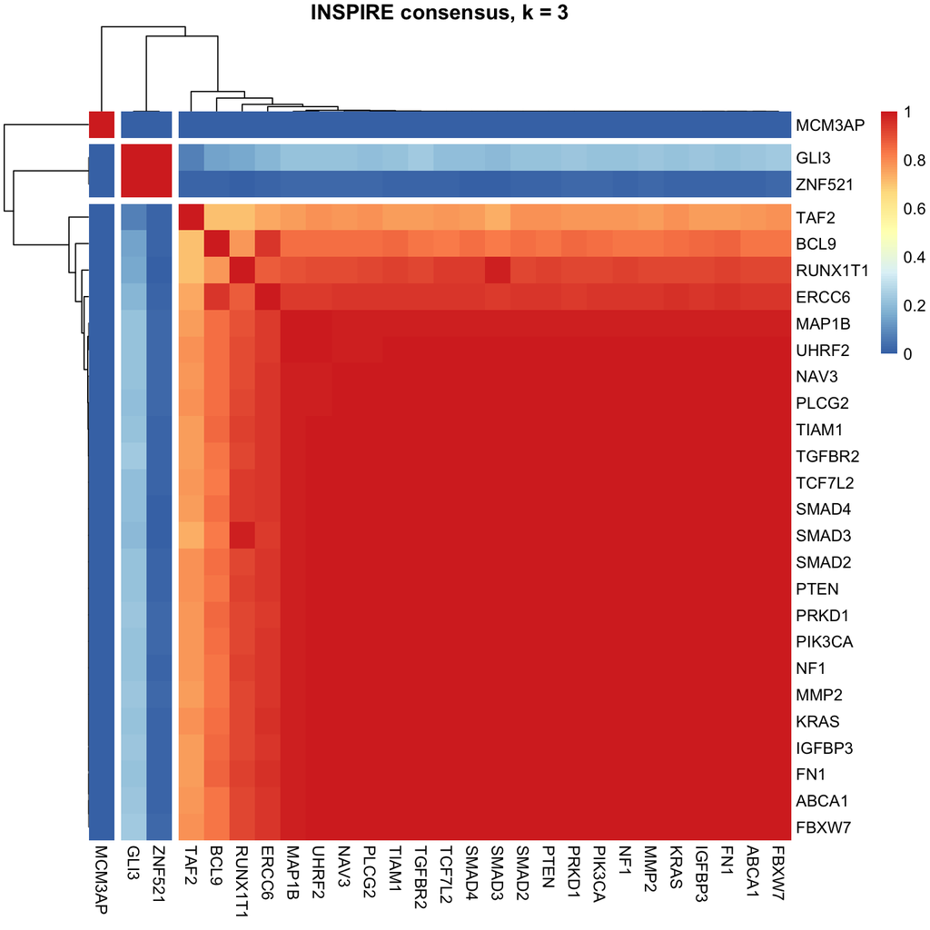

```r
pheatmap(
  consensus_inspire$best$consensus,
  clustering_distance_rows = as.dist(1 - consensus_inspire$best$consensus),
  clustering_distance_cols = as.dist(1 - consensus_inspire$best$consensus),
  clustering_method = "average",
  cutree_rows = k_inspire,
  cutree_cols = k_inspire,
  main = paste0("INSPIRE consensus, k = ", k_inspire),
  border_color = NA
)
```

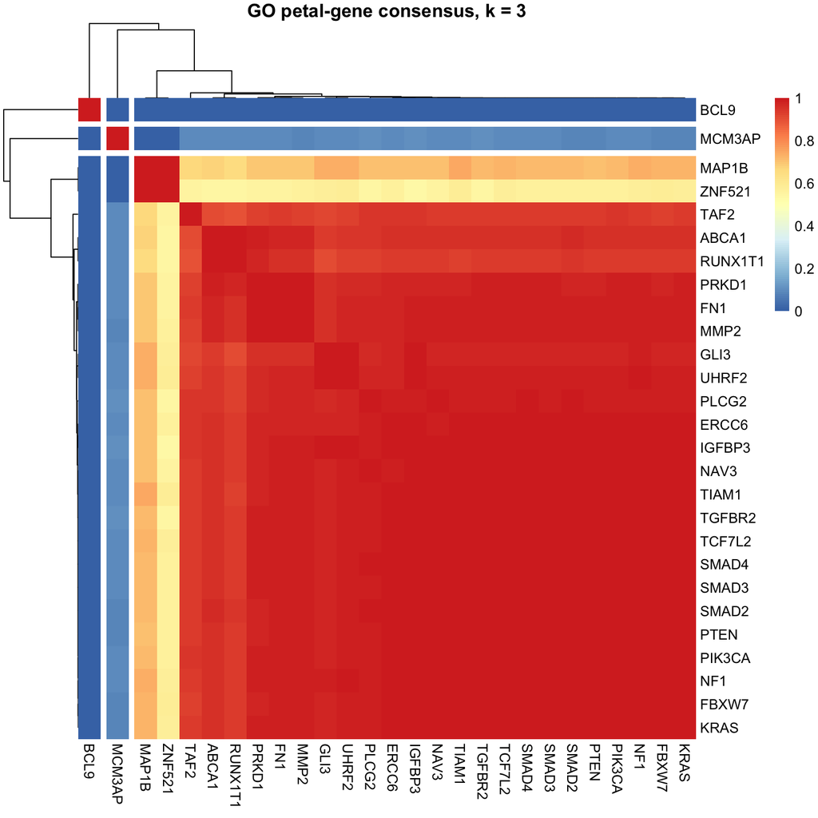

```r
pheatmap(
  consensus_go$best$consensus,
  clustering_distance_rows = as.dist(1 - consensus_go$best$consensus),
  clustering_distance_cols = as.dist(1 - consensus_go$best$consensus),
  clustering_method = "average",
  cutree_rows = k_go,
  cutree_cols = k_go,
  main = paste0("GO petal-gene consensus, k = ", k_go),
  border_color = NA
)
```

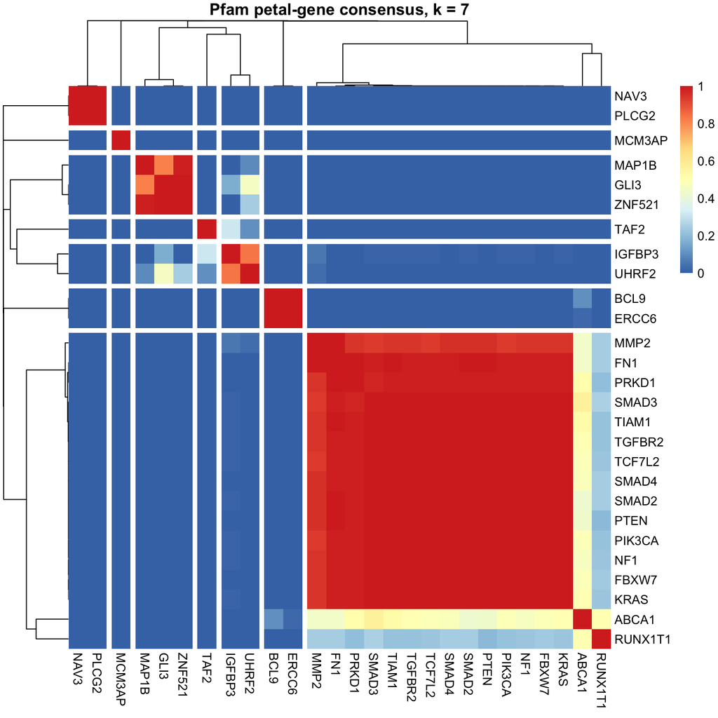

```r
pheatmap(
  consensus_pfam$best$consensus,
  clustering_distance_rows = as.dist(1 - consensus_pfam$best$consensus),
  clustering_distance_cols = as.dist(1 - consensus_pfam$best$consensus),
  clustering_method = "average",
  cutree_rows = k_pfam,
  cutree_cols = k_pfam,
  main = paste0("Pfam petal-gene consensus, k = ", k_pfam),
  border_color = NA
)
```

# 14 Agreement between clusterings

```r
adjusted_rand_index <- function(x, y) {
  contingency <- table(x, y)
  choose_two <- function(z) z * (z - 1) / 2

  observed <- sum(choose_two(contingency))
  row_total <- sum(choose_two(rowSums(contingency)))
  column_total <- sum(choose_two(colSums(contingency)))
  total <- choose_two(sum(contingency))
  expected <- row_total * column_total / total
  maximum <- (row_total + column_total) / 2

  if (maximum == expected) return(1)
  (observed - expected) / (maximum - expected)
}

agreement <- tibble(
  comparison = c(
    "INSPIRE: hclust vs consensus",
    "GO: hclust vs consensus",
    "Pfam: hclust vs consensus",
    "hclust: INSPIRE vs GO",
    "hclust: INSPIRE vs Pfam",
    "hclust: GO vs Pfam",
    "consensus: INSPIRE vs GO",
    "consensus: INSPIRE vs Pfam",
    "consensus: GO vs Pfam"
  ),
  adjusted_rand_index = c(
    adjusted_rand_index(cluster_assignments$inspire_hclust, cluster_assignments$inspire_consensus),
    adjusted_rand_index(cluster_assignments$go_hclust, cluster_assignments$go_consensus),
    adjusted_rand_index(cluster_assignments$pfam_hclust, cluster_assignments$pfam_consensus),
    adjusted_rand_index(cluster_assignments$inspire_hclust, cluster_assignments$go_hclust),
    adjusted_rand_index(cluster_assignments$inspire_hclust, cluster_assignments$pfam_hclust),
    adjusted_rand_index(cluster_assignments$go_hclust, cluster_assignments$pfam_hclust),
    adjusted_rand_index(cluster_assignments$inspire_consensus, cluster_assignments$go_consensus),
    adjusted_rand_index(cluster_assignments$inspire_consensus, cluster_assignments$pfam_consensus),
    adjusted_rand_index(cluster_assignments$go_consensus, cluster_assignments$pfam_consensus)
  )
)

write_csv(
  agreement,
  file.path(params$output_dir, "cluster_agreement_adjusted_rand.csv")
)

agreement
```

```
## # A tibble: 9 × 2
##   comparison                   adjusted_rand_index
##   <chr>                                      <dbl>
## 1 INSPIRE: hclust vs consensus               1
## 2 GO: hclust vs consensus                    1
## 3 Pfam: hclust vs consensus                  1
## 4 hclust: INSPIRE vs GO                      0.333
## 5 hclust: INSPIRE vs Pfam                    0.241
## 6 hclust: GO vs Pfam                         0.164
## 7 consensus: INSPIRE vs GO                   0.333
## 8 consensus: INSPIRE vs Pfam                 0.241
## 9 consensus: GO vs Pfam                      0.164
```

# 15 Database metadata

```r
metadata <- DBI::dbGetQuery(
  con,
  "SELECT key, value FROM metadata ORDER BY key"
)

write_csv(
  metadata,
  file.path(params$output_dir, "database_metadata.csv")
)

metadata
```

```
##                                                       key
## 1                           annotation_loader_last_run_at
## 2                               annotation_loader_version
## 3                                   created_or_updated_at
## 4                                  duplicate_score_policy
## 5                                          edge_direction
## 6                                   go_annotation_version
## 7                                        go_aspect_policy
## 8                                             go_gaf_file
## 9                                        go_gaf_loaded_at
## 10                                          go_gaf_sha256
## 11                                       go_ic_population
## 12                                   go_ic_total_proteins
## 13                                          go_not_policy
## 14                                            go_obo_file
```

[output cut: 71 more lines]

# 16 Disconnect from SQLite

```r
DBI::dbDisconnect(con)
```